# Prediction Assignment Writeup

Joshua Johnson

December 20, 2019

# Background

Using devices such as Jawbone Up, Nike FuelBand, and Fitbit it is now possible to collect a large amount of data about personal activity relatively inexpensively. These type of devices are part of the quantified self movement – a group of enthusiasts who take measurements about themselves regularly to improve their health, to find patterns in their behavior, or because they are tech geeks. One thing that people regularly do is quantify how much of a particular activity they do, but they rarely quantify how well they do it. In this project, your goal will be to use data from accelerometers on the belt, forearm, arm, and dumbell of 6 participants. They were asked to perform barbell lifts correctly and incorrectly in 5 different ways. More information is available from the website here: http://web.archive.org/web/20161224072740/http:/groupware.les.inf.puc-rio.br/har (see the section on the Weight Lifting Exercise Dataset).

# Data Loading and Pre-Processing

## Loading Training and Test data sets

```r
training <-read.csv('pml-training.csv')
Final_Quiz <- read.csv('pml-testing.csv')
```

## Clean data sets

### remove NA vaules and unneeded variables and limiting my training set to the same variables avaiable in Final_Quiz set

```r
Final_Quiz <- Final_Quiz %>% dplyr::select_if(~ !any(is.na(.))) %>% dplyr::mutate(classe = "")
training <- training %>% dplyr::select_if(colnames(.) %in% colnames(Final_Quiz))

training <- training[,-c(1:7)] ##the first 7 columns contains reference variables to individual with no relatiopn to our prediciton
Final_Quiz <- Final_Quiz[,-c(1:7)]
```

## Prediction Models

### Creating a training and tests data set within my training df (75% / 25%)

```r
set.seed(1776)
inTrain <- with(training, createDataPartition(classe, p = 0.75)[[1]])

train <- training[inTrain, ]
test  <- training[-inTrain, ]
```

### Initally I used Random Forest due to its high accuracy rates.

```r
control <- trainControl(method = 'cv', number = 3)
model_rf <- train(classe ~ ., data = train, method = "rf", metric = 'Accuracy', trControl = control)
pred_rf <- predict(model_rf, test)
confusionMatrix(test$classe, pred_rf)
```

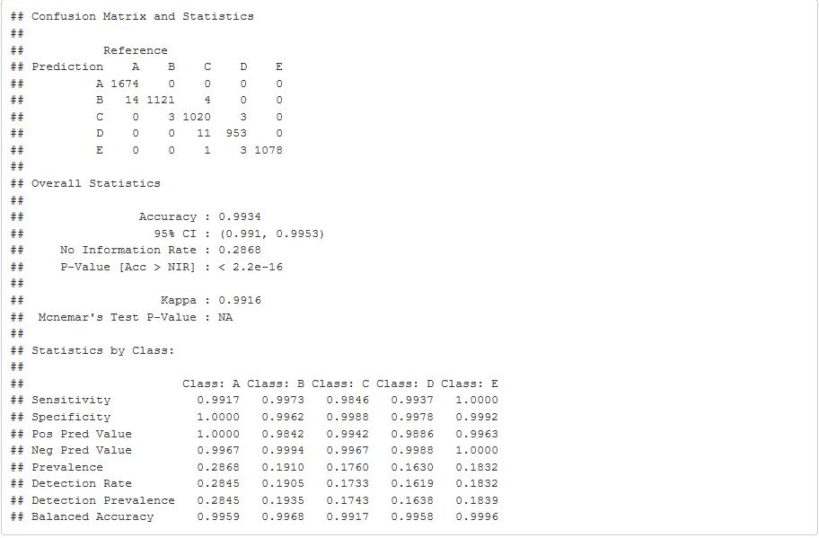

### I then ran a Gradient Boosting Machines also due to its ability to get high accuracy rates.

```r
fitControl <- trainControl(method = "cv", number = 3)

model_gdm <- train(classe ~ ., method = "gbm", data = train, trControl = fitControl, verbose = FALSE)
pred_gdm <- predict(model_gdm, test)
confusionMatrix(test$classe, pred_gdm)
```

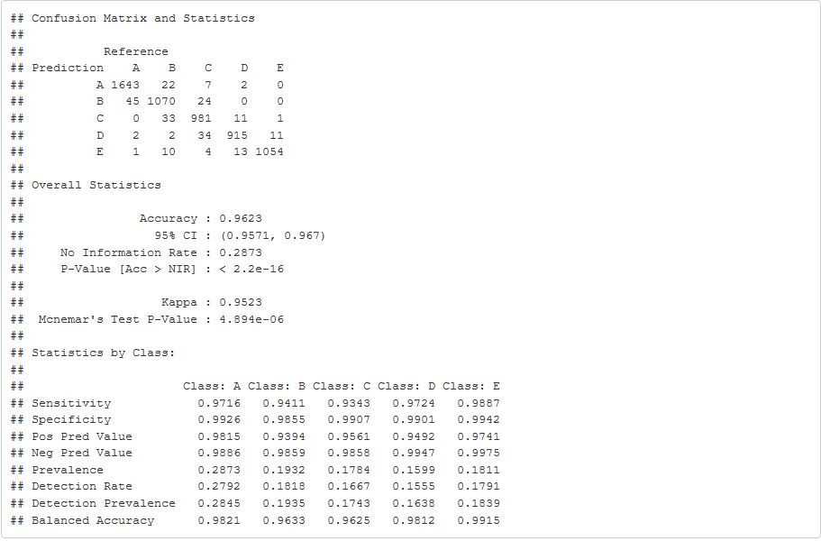

### Lastly, I uesed a Liner Discriminant Analysis. This method proved to process faster but with lower accuracy

```r
model_lda <- train(classe ~ ., method = "lda", data = train)
pred_lda <- predict(model_lda, test)
confusionMatrix(test$classe, pred_lda)
```

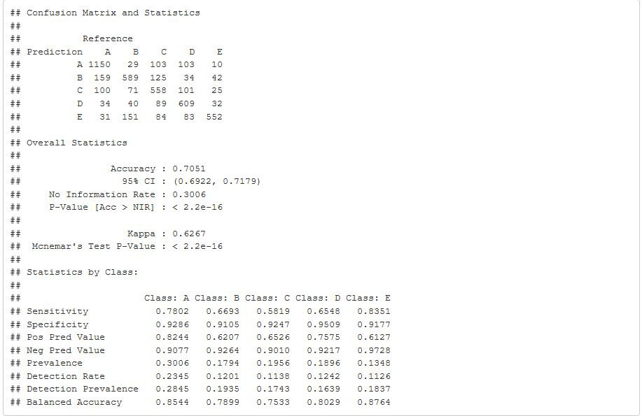

# Random Forest has the highest Predition Accuracy. Hence, we will use this method for predicting our testing data base

```r
Final_pred <- predict(model_rf, newdata = testing)
Final_pred
```

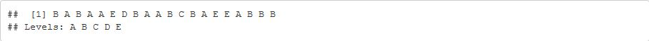